# Week 2 In-class Practice

Ruoqing Zhu

Last Updated: July 18, 2022

## Discussion on p-values

- If we get $p$-value $=0$ (in certain situations we could), can we know for sure that the Null hypothesis is wrong?
- Based on the testing procedure, what is the chance that we make a mistake when the alternative hypothesis is true?
- Discussion: What factors could affect the type II error?

## Distribution of Means

Try to modify the simulation code we had in the simulation example. For each student, let’s generate their score using a uniform distribution from 0 to 100. For each class, let’s assume that there are 50 students. What would the distribution of the average look like? Do you expect it to be a uniform distribution with a narrower range? Try to replicate the simulation study to obtain the 95% upper quantile of that distribution.

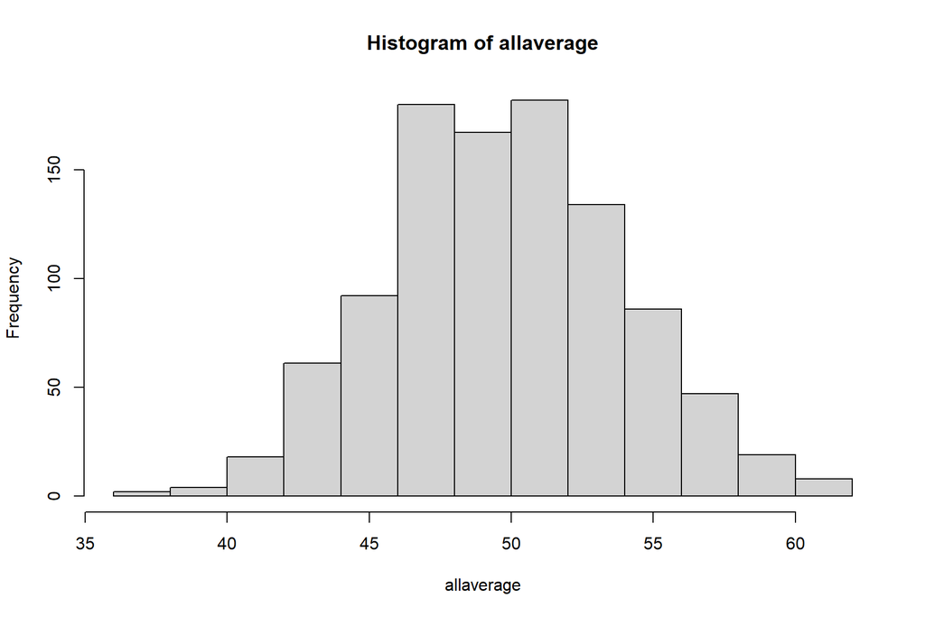

```r
  # Generate 1000 such "classes" and obtain the distribution
  set.seed(3)

  allaverage = rep(NA, 1000)
  for (i in 1:1000)
    allaverage[i] = mean(runif(50, min = 0, max = 100))

  # Now, a surprising result should fall into the top 5% of that distribution
  hist(allaverage)
```

```r
  quantile(allaverage, 0.95)
```

```
##      95%
## 56.91351
```

## z-test

Following the same assumptions as the our z-test question, suppose we are interested in testing whether the average score is **smaller than 95**. Can you obtain the $p$-value of this test?

```r
  pnorm(90 - 95, sd = 15/sqrt(48), lower.tail = TRUE)
```

[output not shown]

## One Sample t-test

If we only get to observe the first 10 observations of the Age variable: `heart$age[1:10]`. Perform the same hypothesis testing problem, what is your conclusion? What is affecting the results? Discuss the impact of having a small sample size.

```r
  heart = read.csv("processed_cleveland.csv")
```

```r
    t.test(heart$age[1:10], mu = 50, alternative = "greater")
```

```
##
##  One Sample t-test
##
## data:  heart$age[1:10]
## t = 2.012, df = 9, p-value = 0.03754
## alternative hypothesis: true mean is greater than 50
## 95 percent confidence interval:
##  50.58694      Inf
## sample estimates:
## mean of x
##      56.6
```

What if we need to test the following hypothesis:

$$H_0: \text{mean age = 60} \quad
\text{vs.} \quad H_1: \text{mean age < 60}$$
Modify the `t.test()` code by changing the `mu` and `alternative` options, and obtain the $p$-value associated with this test.

```r
  t.test(heart$age[1:10], mu = 60, alternative= "less")
```

```
##
##  One Sample t-test
##
## data:  heart$age[1:10]
## t = -1.0365, df = 9, p-value = 0.1635
## alternative hypothesis: true mean is less than 60
## 95 percent confidence interval:
##      -Inf 62.61306
## sample estimates:
## mean of x
##      56.6
```

## Two Sample t-test

A researcher is interested in testing whether the `chol` level is the same for these two groups: Age $<$ 60 and Age $\geq$ 60.

$$H_0: \text{chol}_{\,\text{Age} < 60}
= \text{chol}_{\,\text{Age} \geq 60} \quad \text{vs.} \quad H_1:
\text{chol}_{\,\text{Age} < 60} \neq \text{chol}_{\,\text{Age} \geq
60}$$
Perform the corresponding test using the Cleveland heart disease data. Use a two-sided test, with equal variance assumption.

```r
  chol_smallage = heart$chol[heart$age < 60]
  chol_largeage = heart$chol[heart$age >= 60]
  t.test(chol_smallage, chol_largeage, alternative = "two.sided", var.equal = TRUE)
```

```
##
##  Two Sample t-test
##
## data:  chol_smallage and chol_largeage
## t = -2.7122, df = 301, p-value = 0.007068
## alternative hypothesis: true difference in means is not equal to 0
## 95 percent confidence interval:
##  -30.053855  -4.779858
## sample estimates:
## mean of x mean of y
##  241.4623  258.8791
```

## $\chi^2$ test

First, create two dummy variables from the heart data

- Whether `chol` is greater than 250
- Whether `num` is greater than 0

Test the association between these two variables. What is the $p$ value? What is the clinical meaning of this test?

```r
  chol_new = (heart$chol > 250)
  num_new = (heart$num > 0)
  chisq.test(chol_new, num_new)
```

```
##
##  Pearson's Chi-squared test with Yates' continuity correction
##
## data:  chol_new and num_new
## X-squared = 5.7239, df = 1, p-value = 0.01674
```